# *Proyecto 1 – Relación Minutos Ingreso*

Materia: Machine Learning I

Abril 2024

Integrantes:

- Diego Fernando Alfaro Quintero
- Diana Milena Chaparro Macias
- Mayra Dahian Rosero Franco

## ¿Existe relación alguna entre el total de minutos usados con la compañía y el ingreso total de los clientes?

La revisión del comportamiento de los clientes en cualquier empresa es de vital importancia para el desarrollo de estrategias tanto de mejoramiento de productos como de publicidad y toma de decisiones. Evaluaremos la información del conjunto de registros Credito_dias.csv de una empresa de telecomunicaciones que cuenta las siguientes variables:

totrev: Ingresos del cliente.

totmou: Total de minutos usados por el cliente.

creditcd: Indicador de tarjeta de crédito.

eqpdays: Número de días (antigüedad) del equipo actual.

Es importante mencionar que la empresa contiene una gran cantidad de clientes y hacer el análisis uno a uno no es lo óptimo. Con ayuda de la programación y el análisis de datos, se logrará llegar a conclusiones rápidas y acertadas para encontrar relaciones que a simple vista no son tenidas en cuenta.

## ¿Qué se quiere identificar?

Teniendo en cuenta la información de la base de datos, se quiere identificar si hay una relación entre el total de minutos usados por el cliente con la compañía y el ingreso total de los clientes, es decir, ¿Será posible afirmar que cuando una persona tiene un mayor ingreso, entonces es mayor la utilización de minutos o todo lo contrario?

Incluyan un exploratorio separado por cada una de las variables que se tienen en esta base se sugiere que use histogramas para las variables numéricas y diagramas de barras para las categóricas.

### 1. Análisis exploratorio de las variables

Se importan las librerías necesarias para el manejo de los datos

```python
import pandas as pd
import seaborn as sns
import matplotlib.pyplot as plt
sns.set(style='whitegrid', context='notebook')
```

Se importa la base de datos en la variable df

```python
df = pd.read_csv('https://raw.githubusercontent.com/Izainea/seminario-de-programacion/master/Cuadernos/Clase%202/Bases/Credito_dias.csv')
```

Se obtiene el tamaño de la base de datos

```python
df.shape
```

```
(10000, 5)
```

Con la función info, se obtiene información sobre la cantidad y el tipo de dato de cada variable.

```python
df.info()
```

```
<class 'pandas.core.frame.DataFrame'>
RangeIndex: 10000 entries, 0 to 9999
Data columns (total 5 columns):
 #   Column       Non-Null Count  Dtype
---  ------       --------------  -----
 0   totmou       10000 non-null  float64
 1   totrev       10000 non-null  float64
 2   creditcd     9848 non-null   object
 3   eqpdays      10000 non-null  int64
 4   Customer_ID  10000 non-null  int64
dtypes: float64(2), int64(2), object(1)
memory usage: 390.8+ KB
```

De acuerdo a la información observada de la base de datos, se evidencia que hay campos vacíos en la variable 'creditcd', por lo que se decide eliminar los registros que contienen información nula en la variable mencionada. Esto se realiza con la función notna(). Se almacenan los datos filtrados en la variable df_copy.

```python
df_copy = df[df['creditcd'].notna()]
```

Se obtienen los estadísticos de las variables numéricas.

```python
df_copy.describe()
```

|  | totmou | totrev | eqpdays | Customer_ID |
| --- | --- | --- | --- | --- |
| count | 9848.000000 | 9848.000000 | 9848.000000 | 9.848000e+03 |
| mean | 7697.900458 | 1042.302115 | 386.982433 | 1.049854e+06 |
| std | 8662.012934 | 857.945971 | 252.473800 | 2.875331e+04 |
| min | 0.000000 | 11.100000 | -5.000000 | 1.000014e+06 |
| 25% | 2575.000000 | 526.627500 | 210.000000 | 1.024992e+06 |
| 50% | 5261.500000 | 820.955000 | 338.000000 | 1.049404e+06 |
| 75% | 9842.000000 | 1272.975000 | 523.000000 | 1.074646e+06 |
| max | 163264.176700 | 13426.600000 | 1823.000000 | 1.099992e+06 |

Para realizar el análisis exploratorio de cada variable, primero se grafican las variables numéricas totmou, totrev, eqpdays.

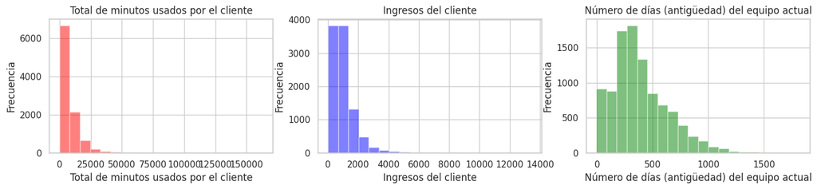

```python
#Se escogen las variables más immportantes para realizar la regresión
cols = ['totmou', 'totrev','eqpdays']
colors = ['red', 'blue', 'green']
titles = ['Total de minutos usados por el cliente','Ingresos del cliente','Número de días (antigüedad) del equipo actual']
fig, axs = plt.subplots(1,3, figsize=(3,3))

for i in range(len(cols)):
    axs[i].hist(df_copy[cols[i]], color=colors[i], bins = 20, alpha = 0.5)
    axs[i].set_title(titles[i])
    axs[i].set_xlabel(titles[i])
    axs[i].set_ylabel('Frecuencia')


plt.subplots_adjust(right=4.5)
plt.show()
```

Se visualiza la variable categórica 'creditcd'

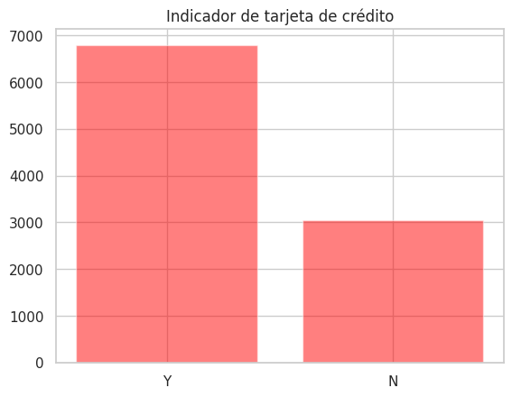

```python
cols = ['creditcd']
colors = ['red', 'blue', 'green']
titles = ['Indicador de tarjeta de crédito']
i = 0
plt.bar(df_copy[cols[i]].unique(),df_copy[cols[i]].value_counts(), color = colors[i], alpha=0.5)
plt.title(titles[i])
plt.show()
```

En los histogramas es posible evidenciar que la mayoría de los clientes usan menos de 25.000 minutos e ingresan menos de 2.000 veces. Se evidencian datos fuera rango de la media y mediana que no permiten evidenciar la normalidad de los datos.

# 2. Diagrama de dispersión entre las variables totrev y totmou

Se realiza un diagrama de dispersión entre las variables totrev y totmou para posteriomente desarrollar una conclusión.

[figure not shown]

```python
sns.scatterplot(data = df_copy, x = "totmou", y = "totrev", alpha = 0.5)
plt.ylabel('Total de minutos por cliente')
plt.xlabel('Total de ingresos por cliente')
plt.title('Minutos por cliente vs Ingresos por cliente')
```

```python
Corr_minutos_ingresos= df_copy[[ "totmou" ,"totrev" ]].corr()
print(Corr_minutos_ingresos)
```

```
          totmou    totrev
totmou  1.000000  0.835279
totrev  0.835279  1.000000
```

# 3. ¿Existe relación alguna entre el total de minutos usados con la compañía y el ingreso total de los clientes?

De acuerdo con los resultados podemos decir que hay una correlación alta entre el total de minutos usados con la compañía y el ingreso total de los clientes con un coeficiente de 0.835279 y por lo tanto tiene una alta incidencia la una en la otra.

El hecho de tener crédito afecta alguna de estas dos variables, compruébenlo incluyendo en el diagrama de dispersión una leyenda que indique si tiene crédito o no.

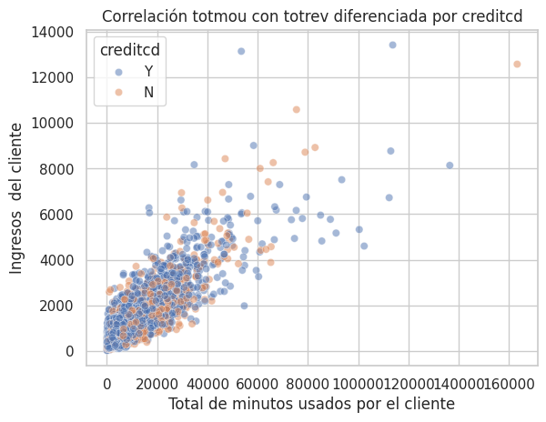

```python
ax = sns.scatterplot(data = df_copy, x = "totmou", y = "totrev", hue = "creditcd", alpha = 0.5);

plt.title('Correlación totmou con totrev diferenciada por creditcd');
plt.xlabel('Total de minutos usados por el cliente');
plt.ylabel('Ingresos  del cliente');
```

```python
df_copy['creditcd'].replace(['N', 'Y'],[0, 1], inplace=True)

import scipy.stats as stats
print("\n", stats.pointbiserialr(df_copy['creditcd'], df_copy['totmou']))
print("\n", stats.pointbiserialr(df_copy['creditcd'], df_copy['totrev']))
print("\n", df_copy.corr())
```

```
 SignificanceResult(statistic=-0.045701158129930544, pvalue=5.704801199873564e-06)

 SignificanceResult(statistic=0.004963203463193362, pvalue=0.6223840289940756)

                totmou    totrev  creditcd   eqpdays  Customer_ID
totmou       1.000000  0.835279 -0.045701 -0.111589    -0.282877
totrev       0.835279  1.000000  0.004963  0.060361    -0.472679
creditcd    -0.045701  0.004963  1.000000  0.118590    -0.138433
eqpdays     -0.111589  0.060361  0.118590  1.000000    -0.407590
Customer_ID -0.282877 -0.472679 -0.138433 -0.407590     1.000000
```

La correlación entre creditcd y totmou al tener p-value < 0.05 existe (Se niega la hipótesis nula) pero al ser cercana a 0, no existe correlación entre ambas variables.

La correlación entre creditcd y totrev no tiene significancia estadística, por lo que se acepta la hipótesis nula (no hay correlación).

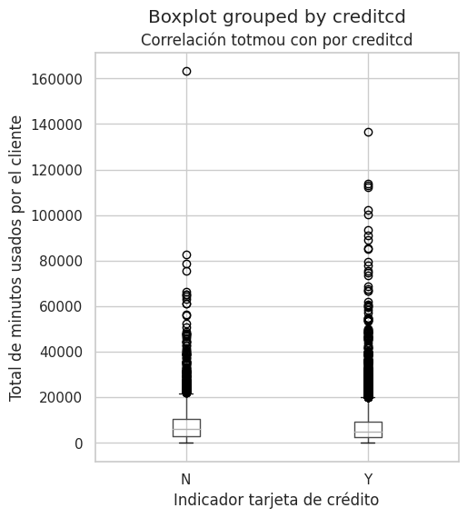

```python
df.boxplot(column = 'totmou', by = 'creditcd', figsize = (5,6));
plt.title('Correlación totmou con por creditcd');
plt.xlabel('Indicador tarjeta de crédito');
plt.ylabel('Total de minutos usados por el cliente');
```

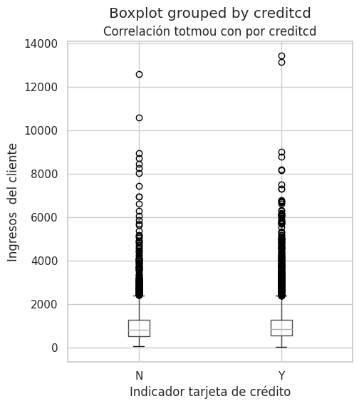

```python
df.boxplot(column = 'totrev', by = 'creditcd', figsize = (5,6));
plt.title('Correlación totmou con por creditcd');
plt.xlabel('Indicador tarjeta de crédito');
plt.ylabel('Ingresos  del cliente');
```

## Conclusión

Como se observa en ambos gráficos box-plot las cajas (50% de los registros) están alineados para valores false y true de la variable creditcd, por lo que validamos visualmente también que no hay correlación entre totmou y creditcd, ni entre totrev y creditcd.